# Understanding the ERA Hexbin SHAP Visualization Script

2025-05-30

# Introduction

This document explains the R script used to create hexbin visualizations of SHAP (SHapley Additive exPlanations) values for the ERA project. The script generates visualizations that show SHAP importance across different Agro-Ecological Zones (AEZs) in Africa using hexbin plots. These visualizations help understand how different climate variables interact to influence crop yields and how these interactions vary across regions.

# Libraries and Dependencies

```r
library(ggplot2)      # Core plotting functionality
library(hexbin)       # For creating hexagonal binning plots
library(patchwork)    # For combining multiple plots
library(dplyr)        # For data manipulation
library(stringr)      # For string manipulation
library(ggrepel)      # For non-overlapping text labels
library(shadowtext)   # For text with background/shadow effects
source('R/hexbin_grid.R')  # Custom functions for hexbin grid creation
```

The script relies on several R packages, with the core visualization being handled by `ggplot2` and `hexbin`. It also sources a custom R function file `hexbin_grid.R` that contains specialized functions for creating the hexbin grid layouts.

The script requires selection between “Warm” and “Cool” AEZ temperature regimes, which determines which set of agro-ecological zones will be visualized. It also specifies the experiment name, which is used to locate the appropriate data files.

# Data Loading and Feature Selection

## Warm AEZs Configuration

```r
if (AEZ_temp == "Warm"){
  max_importance <- 500
  features_list <- list(
    c("Avg_Max_Temp", "Total_Rainfall_Dev", "Total_Rainfall", "Avg_Max_Temp_Dev"),
    c("Avg_Max_Temp", "Avg_Max_Temp_Dev", "Longest_Dry_Spell", "Total_Rainfall"),
    c("Total_Rainfall", "Avg_Max_Temp_Dev", "Total_Rainfall_Dev", "Fraction_Rainy_Days"))

  custom_log_breaks <- c(1, 4, 16, 64, 256)

  AEZ_names <- c("Warm Semiarid", "Warm Subhumid", "Warm Humid")
  # Read data for Warm Semiarid
  results <- readRDS(paste0("outputs/", experiment, "_Warm.Semiarid/full_results/full_results.rds"))
  cv_results <- readRDS(paste0("outputs/", experiment, "_Warm.Semiarid/full_results/cv_results.rds"))
  shap_list[[1]] <- results$shap_values
  cv_importance_list[[1]] <- cv_results$shap_plot

  # Read data for Warm Subhumid
  results <- readRDS(paste0("outputs/", experiment, "_Warm.Subhumid/full_results/full_results.rds"))
  cv_results <- readRDS(paste0("outputs/", experiment, "_Warm.Subhumid/full_results/cv_results.rds"))
  shap_list[[2]] <- results$shap_values
  cv_importance_list[[2]] <- cv_results$shap_plot

  # Read data for Warm Humid
  results <- readRDS(paste0("outputs/", experiment, "_Warm.Humid/full_results/full_results.rds"))
  cv_results <- readRDS(paste0("outputs/", experiment, "_Warm.Humid/full_results/cv_results.rds"))
  shap_list[[3]] <- results$shap_values
  cv_importance_list[[3]] <- cv_results$shap_plot
}
```

## Cool AEZs Configuration

```r
if(AEZ_temp == "Cool"){
  max_importance <- 750

  features_list <- list(
    c("Total_Rainfall", "Avg_Max_Temp_Dev", "Total_Rainfall_Dev", "Avg_Max_Temp"),
    c("Avg_Max_Temp", "Total_Rainfall", "Fraction_Rainy_Days", "Total_Rainfall_Dev"),
    c("Avg_Max_Temp_Dev", "Fraction_Rainy_Days_Dev", "Total_Rainfall", "Avg_Max_Temp"))

  custom_log_breaks <- c(1, 4, 16, 64, 150)

  AEZ_names <- c("Cool Semiarid", "Cool Subhumid", "Cool Humid")
  # Read data for Cool Semiarid
  results <- readRDS(paste0("outputs/", experiment, "_Cool.Semiarid/full_results/full_results.rds"))
  cv_results <- readRDS(paste0("outputs/", experiment, "_Cool.Semiarid/full_results/cv_results.rds"))
  shap_list[[1]] <- results$shap_values
  cv_importance_list[[1]] <- cv_results$shap_plot

  # Read data for Cool Subhumid
  results <- readRDS(paste0("outputs/", experiment, "_Cool.Subhumid/full_results/full_results.rds"))
  cv_results <- readRDS(paste0("outputs/", experiment, "_Cool.Subhumid/full_results/cv_results.rds"))
  shap_list[[2]] <- results$shap_values
  cv_importance_list[[2]] <- cv_results$shap_plot

  # Read data for Cool Humid
  results <- readRDS(paste0("outputs/", experiment, "_Cool.Humid/full_results/full_results.rds"))
  cv_results <- readRDS(paste0("outputs/", experiment, "_Cool.Humid/full_results/cv_results.rds"))
  shap_list[[3]] <- results$shap_values
  cv_importance_list[[3]] <- cv_results$shap_plot
}
```

Based on the selected AEZ temperature regime (Warm or Cool), the script:

1. Sets the maximum importance value for consistent scaling across visualizations
2. Defines the list of features to be visualized for each AEZ
3. Sets custom logarithmic break points for the visualizations
4. Loads both the SHAP values and cross-validation results for each of the three AEZs (Semiarid, Subhumid, Humid)

For each temperature regime, the script loads data from previously computed Random Forest models: - `full_results.rds`: Contains SHAP values from the full model trained on all training data - `cv_results.rds`: Contains cross-validation results and feature importance plots

Note that different feature sets are prioritized for visualization in Warm versus Cool AEZs, reflecting the distinct climate dynamics that drive agricultural outcomes in these different regions. These were selected based on MDA feature importance.

# Performance Metrics Loading

The script loads the performance metrics summary table that contains model evaluation statistics for each AEZ.

```r
performance_metrics <- read.csv(paste0("final_results/", experiment, "_performance_metrics.csv"))
performance_metrics$AEZ <- gsub("\\.", " ", performance_metrics$AEZ)
```

# Plot Modification

This code chunk makes some modifications to improve visualization and consistency.

```r
# Only show title for the first plot, and show stats for all plots
for (i in seq_along(cv_importance_list)) {
  aez_performance <- performance_metrics %>%
    filter(AEZ == AEZ_names[i])
  cv_importance_list[[i]] <- modify_importance_plot_with_data(
    cv_importance_list[[i]],
    AEZ_name = AEZ_names[i],
    R2 = aez_performance$Full_Test_R2,
    n_obs = aez_performance$N_obs,
    max_importance = max_importance,
    show_title = (i == 1),  # Only show title for the first plot
    show_stats = TRUE
  )
}
```

# Creating and Saving the Visualization Grid

The hexbin plots are groupped in a 3x5 grid (AEZ x Feature).

```r
# Create the plot grid with modified CV importance plots and custom log breaks
plot_grid <- create_shap_hexbin_grid_with_cv(
  data_list = shap_list,
  features_list = features_list,
  cv_importance_list = cv_importance_list,
  row_names = NULL,
  title = "",
  show_correlation = FALSE,
  add_trend_line = FALSE,
  n_x_breaks = 4,
  k = 3,
  custom_log_breaks = custom_log_breaks
)

# Display the plot
print(plot_grid)

# Save the figure
ggsave(
  paste0("final_results/", AEZ_temp , "_hexbinc.pdf"),
  plot = plot_grid,
  width = 180,              # Width in mm
  height = 160,             # Height in mm
  units = "mm",
  dpi = 300
)
ggsave(
  paste0("final_results/", AEZ_temp , "_hexbinc.png"),
  plot = plot_grid,
  width = 180,              # Width in mm
  height = 160,             # Height in mm
  units = "mm",
  dpi = 300
)
```

They will look like this for the Warm AEZs:

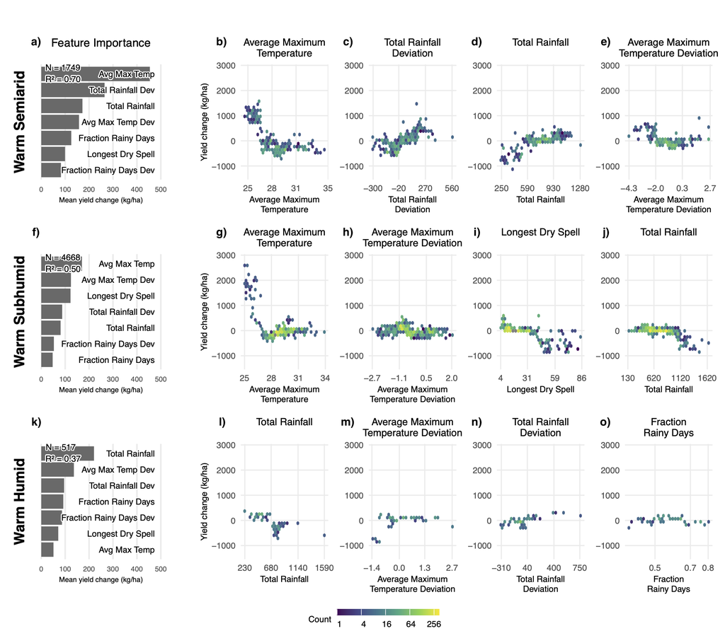

Warm AEZs Hexbin plot

and for the the Cool AEZs:

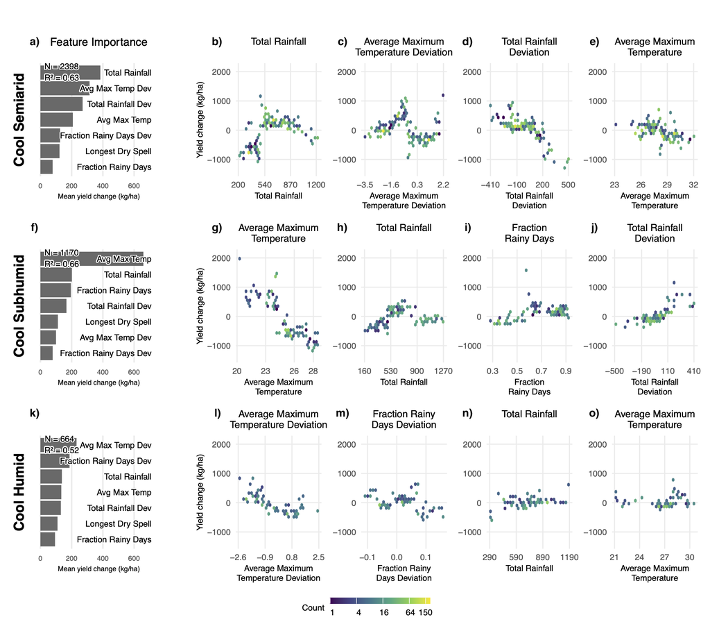

Cool AEZs Hexbin plot

# Understanding the Hexbin Visualization

## Feature Importance Plots (Left Column)

- Bar charts showing the relative importance of features in predicting crop yields
- Features ordered by importance, with the most important at the top
- Performance statistics (R², number of observations) for each AEZ

## SHAP Interaction Hexbin Plots (Right Columns)

- Hexagonal binning plots that show the density of data points
- X-axis: Feature values
- Y-axis: SHAP values (impact on model prediction)
- Color: Density of observations (logarithmic scale)
- Each row corresponds to a different AEZ (Semiarid, Subhumid, Humid)
- Each column pair examines a different feature relationship

## Interpreting the Plots

The hexbin plots reveal:

1. **Feature Effects**: How each feature’s value relates to its impact on yield predictions (positive or negative)
2. **Feature Distributions**: Where most observations fall within the feature space (indicated by hexagon color intensity)
3. **Regional Differences**: How feature effects and distributions vary across different AEZs
4. **Feature Interactions**: By comparing the same feature across different AEZs or different features within an AEZ

## Example Insights

From these visualizations, researchers can identify patterns such as:

- Temperature thresholds beyond which crop yields decline rapidly
- Rainfall levels that are optimal for different climate zones
- How drought indicators (like dry spell length) impact yields differently across regions
- Whether variability or absolute values of climate variables are more important in different contexts

# Conclusion

This script creates hexbin subplot visualizations that help understand the complex relationships between climate variables and agricultural yields across different ecological zones in Africa.